# 3

Raigardas Balužis

January 20, 2017

# Užduotis 3

1. Nuskaitykite duomenų masyvą. Jeigu įmanoma, nekoreguokite originalaus failo.

```r
data = read.csv("data.csv", header = TRUE, sep = ";", dec = ".", skip = 7)
```

2. Paruoškite duomenis naudojimui. Jūs turite užtikrinti, kad:
- Neliko įrašų su trūkstamomis reikšmėmis - jeigu šalinote įrašus, tai būtinai raportuokite kiek įrašų pašalinta ir kiek liko.

```r
data[data == "MISSING"] <- NA
NAs = rowSums(is.na(data))                           # Panaikinam NA
fixed_data = data[NAs == 0,]                         # Duomenys be NA
sum(NAs)                                             # Kiek eilučių buvo su NA(t.y. kiek panaikinom)
```

```
## [1] 5
```

```r
nrow(fixed_data)                                     # Kiek eilučių liko po NA pašalinimo
```

```
## [1] 347
```

- Duomenų masyve nėra kažkokių klaidų (pvz. negalimos reikšmės, neteisingas duomenų tipas, t.t.). Patartina patikrinti visų duomenų tipus, nes kartais nuskaitymo procedūra suinterpretuoja duoenis ne taip kaip tikimasi.

```r
sapply(fixed_data, class)
```

```
##       kaina        rida      amzius       galia markesKodas
##    "factor"   "numeric"    "factor"   "integer"    "factor"
```

```r
fixed_data$kaina = as.numeric(fixed_data$kaina)
fixed_data$amzius = as.numeric(fixed_data$amzius)
sapply(fixed_data, class)
```

```
##       kaina        rida      amzius       galia markesKodas
##   "numeric"   "numeric"   "numeric"   "integer"    "factor"
```

3. Pateikite trumpą kintamųjų apžvalgą. Naudokite tik tuos duomenis (ir kintamuosius), kuriuos planuojate taikyti tyrimui, t.y. jei reikėjo ką nors modifikuoti, tai senųjų reikšmių naudoti nebereikia. Šiai apžvalgai užtenka informacijos, kurią pateikia funkcijos plot, summary ir cor.

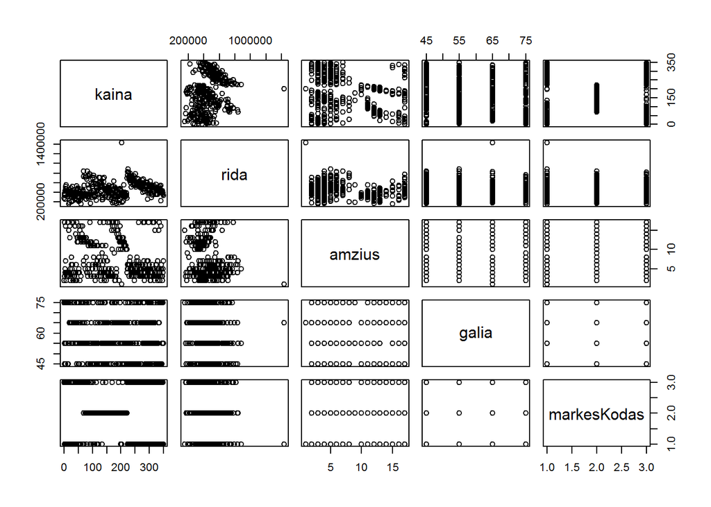

```r
plot(fixed_data)
```

```r
summary(fixed_data)
```

```
##      kaina            rida             amzius           galia
##  Min.   :  1.0   Min.   : 154691   Min.   : 1.000   Min.   :45.00
##  1st Qu.: 87.5   1st Qu.: 357303   1st Qu.: 4.000   1st Qu.:55.00
##  Median :174.0   Median : 445733   Median : 5.000   Median :55.00
##  Mean   :174.6   Mean   : 460964   Mean   : 7.357   Mean   :59.03
##  3rd Qu.:261.5   3rd Qu.: 547409   3rd Qu.:11.000   3rd Qu.:65.00
##  Max.   :349.0   Max.   :1436011   Max.   :17.000   Max.   :75.00
##  markesKodas
##  bm:117
##  ky:118
##  qt:112
##
##
##
```

```r
cor(fixed_data[,1:4])
```

```
##              kaina        rida       amzius        galia
## kaina   1.00000000  0.23201747 -0.209356825 -0.036122413
## rida    0.23201747  1.00000000 -0.234390986 -0.027008134
## amzius -0.20935682 -0.23439099  1.000000000 -0.000016821
## galia  -0.03612241 -0.02700813 -0.000016821  1.000000000
```

4. Duomenų masyvą suskaidykite į du atskirus ir nesikertančius masyvus. Didesnį masyvą turi sudaryti apie 80 proc. turimų stebėjimų. Šį masyvą vadinsime trainSet. Mažesnį masyvą turi sudaryti likę įrašai. Šį masyvą vadinsime testSet. Duomenų suskaidymas turi būti atsitiktinis. Gali būti naudingos šios funkcijos:sample, setdiff, %in%.

```r
trainSet_ind = sample(1:nrow(fixed_data), round(nrow(fixed_data)*0.8)) # Atsitiktinių indeksų aibė (80% duomenų)
testSet_ind = setdiff(1:nrow(fixed_data), trainSet_ind)                # Atsitiktinių indeksų aibė, (20% duomenų)
trainSet = fixed_data[trainSet_ind,]                                   # 80%
testSet = fixed_data[testSet_ind,]                                     # 20%
```